# Golf Project

Harsh Dave

2/17/2020

### 1. Data set `PGA.csv` contains statistics of performance and winnings for 196 PGA tour participants during 2004 season [https://www.pgatour.com/]. Here is the list of variable: Name, Age, Average Drive (Yards), Driving accuracy (percent), Greens on regulation (%), Average # of putts, Save Percent, Money Rank, # Events, Total Winnings ($), Average winnings ($). Please read PGA data (PGA.csv) into R.

```r
setwd("C:/Users/harsh/Documents")
pga <- read.csv("PGA.csv")
```

### 2. Visualize the data **concisely** using scatter plots and histograms. For example, you can use R functions such as `pairs()`, `hist()`, and `pairs.panels()` in the R package `psych`. Briefly describe the visualization results, e.g., outliers, skewness, strong correlations, clusters, and so on.

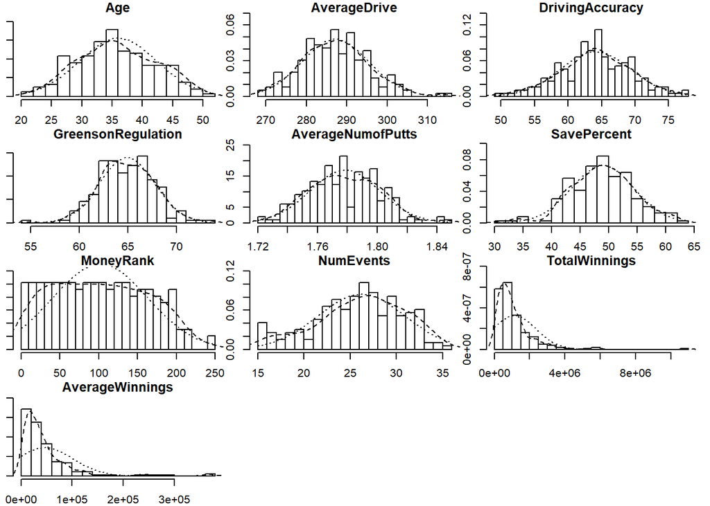

```r
library("psych")
multi.hist(pga[2:11])
```

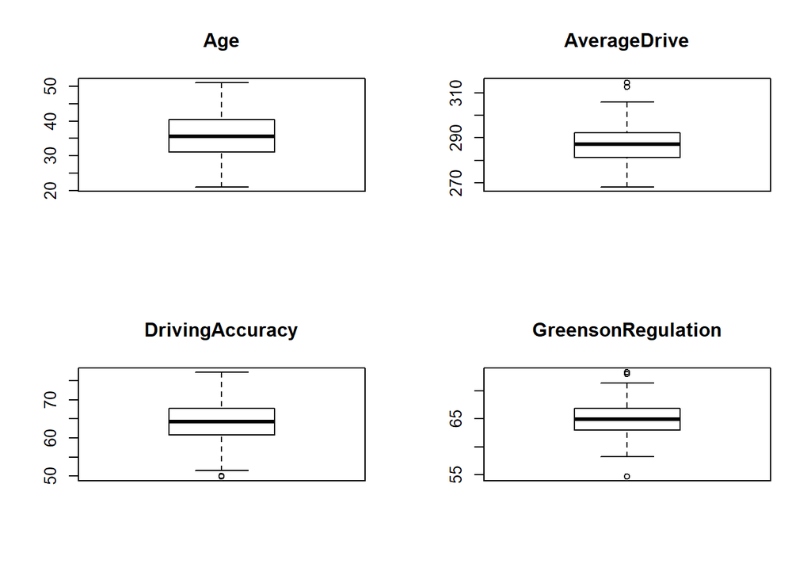

```r
par(mfrow=c(2,2))
boxplot(pga[2],main="Age")
boxplot(pga[3],main="AverageDrive")
boxplot(pga[4],main="DrivingAccuracy")
boxplot(pga[5],main="GreensonRegulation")
```

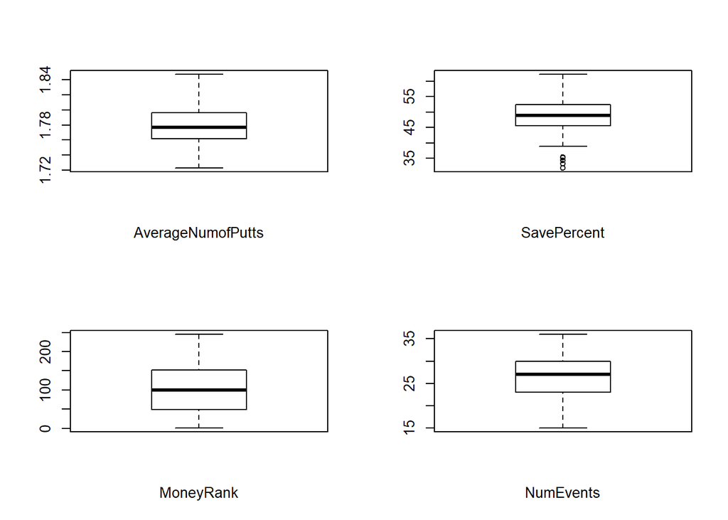

```r
boxplot(pga[6],xlab="AverageNumofPutts")
boxplot(pga[7],xlab="SavePercent")
boxplot(pga[8],xlab="MoneyRank")
boxplot(pga[9],xlab="NumEvents")
```

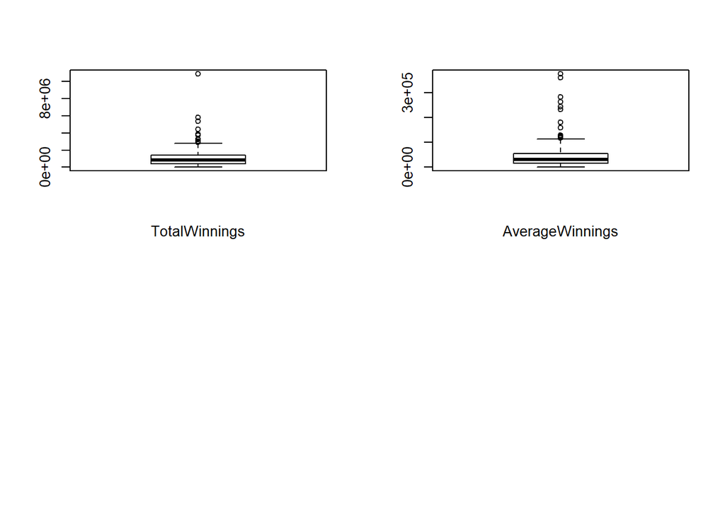

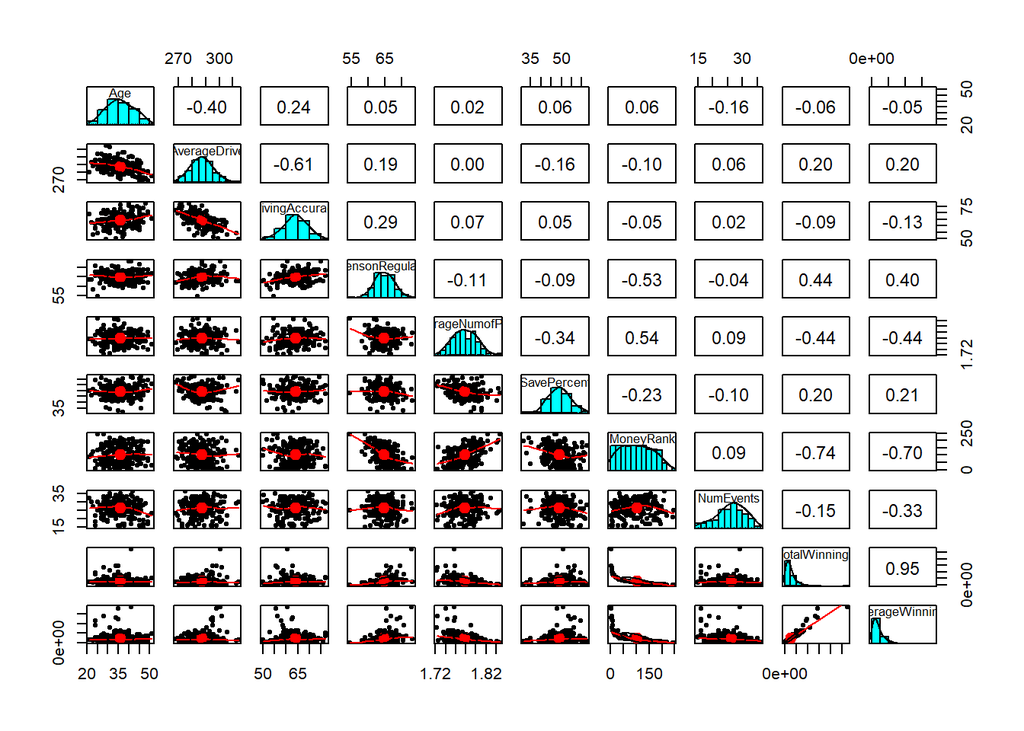

```r
boxplot(pga[10],xlab="TotalWinnings")
boxplot(pga[11],xlab="AverageWinnings")
pairs.panels(pga[2:11])
```

#### Observations for multiple histograms:

1. The variables Age, AverageDrive, DrivingAccuracy, SavePercent and NumEvents are normally distributed.
2. The variables TotalWinnings and Average Winnings are positively skewed from the mean value.
3. Histogram analysis depicts that there maybe outliers for the variables. We will confirm this be performing Box and Whiskers plot analysis.

#### Observations for Box and Whiskers plots:

1. There are outliers in AverageDrive,Savepercent,GreensonRegulation and Total Winnings.

### 3. Fit a multiple linear regression to the data. Use Average winnings as the response variable and use Age, Average Drive (Yards), Driving Accuracy (percent), Greens on Regulation (%), Average # of Putts, Save Percent, and # Events as covariates. Based on the regression results, which covariate has the largest estimated slope (in absolute value)? Which covariates are important in terms of the association with the response variable?

```r
model <- lm(AverageWinnings ~ Age + AverageDrive + DrivingAccuracy + GreensonRegulation + AverageNumofPutts + SavePercent + NumEvents ,data=pga)
summary(model)
```

```
##
## Call:
## lm(formula = AverageWinnings ~ Age + AverageDrive + DrivingAccuracy +
##     GreensonRegulation + AverageNumofPutts + SavePercent + NumEvents,
##     data = pga)
##
## Residuals:
##    Min     1Q Median     3Q    Max
## -71690 -22176  -6735  17147 247928
##
## Coefficients:
##                      Estimate Std. Error t value Pr(>|t|)
## (Intercept)         945579.88  305886.59   3.091  0.00230 **
## Age                   -587.13     519.32  -1.131  0.25968
## AverageDrive           -94.76     567.42  -0.167  0.86755
## DrivingAccuracy      -2360.57     854.02  -2.764  0.00628 **
## GreensonRegulation    8466.04    1303.87   6.493 7.30e-10 ***
## AverageNumofPutts  -694226.49  138155.99  -5.025 1.17e-06 ***
## SavePercent           1395.67     587.54   2.375  0.01853 *
## NumEvents            -3159.22     644.24  -4.904 2.03e-06 ***
## ---
## Signif. codes:  0 '***' 0.001 '**' 0.01 '*' 0.05 '.' 0.1 ' ' 1
##
## Residual standard error: 41430 on 188 degrees of freedom
## Multiple R-squared:  0.4527, Adjusted R-squared:  0.4323
## F-statistic: 22.21 on 7 and 188 DF,  p-value: < 2.2e-16
```

### 4. Based on the fitted regression, is AverageDrive a covariate with statistically significant nonzero slope? State your conclusion and reasons.

No, AverageDrive is not a co-variate with statistically significant absolute slope. Infact, it has the smallest slope when comapred with other estimated values of slope. This observation is further supported when we investigate the t-value and p-value for AverageDrive. The p-value is very high for AverageDrive which signifies weak correlation with response variable.

### 5. If you run a simple linear regression of `lm(AverageWinnings ~ AverageDrive, data=d)`, is AverageDrive a covariate with statistically significant nonzero slope in this case? State your conclusion and reasons.

```r
model1 <- lm(AverageWinnings ~ AverageDrive, data=pga)
summary(model1)
```

```
##
## Call:
## lm(formula = AverageWinnings ~ AverageDrive, data = pga)
##
## Residuals:
##    Min     1Q Median     3Q    Max
## -62001 -28630 -13234  10847 311571
##
## Coefficients:
##               Estimate Std. Error t value Pr(>|t|)
## (Intercept)  -331133.4   134365.6  -2.464  0.01459 *
## AverageDrive    1315.2      467.7   2.812  0.00543 **
## ---
## Signif. codes:  0 '***' 0.001 '**' 0.01 '*' 0.05 '.' 0.1 ' ' 1
##
## Residual standard error: 54040 on 194 degrees of freedom
## Multiple R-squared:  0.03916,    Adjusted R-squared:  0.03421
## F-statistic: 7.907 on 1 and 194 DF,  p-value: 0.005429
```

Yes, after analysing the linear regression model above we can consider the Average drive as a significant co-variate. The only reason as to why it was insignificant in the initial regression model could be that the initial model was violating assumptions of linear regression. Model Adequacy checking needs to be done in this case to validate if all the independent variables are not correlated with each other. ### 6. If you run a multiple linear regression similar to the one in question 3 except you remove Driving Accuracy as a covariate, is AverageDrive a significant covariate with nonzero slope in this case? Are these results consistent or contradicted with the results in questions 4 and 5? State your conclusion and reasons.

```r
model2 <- lm(AverageWinnings ~ Age + AverageDrive + GreensonRegulation + AverageNumofPutts + SavePercent + NumEvents ,data=pga)
summary(model2)
```

```
##
## Call:
## lm(formula = AverageWinnings ~ Age + AverageDrive + GreensonRegulation +
##     AverageNumofPutts + SavePercent + NumEvents, data = pga)
##
## Residuals:
##    Min     1Q Median     3Q    Max
## -72734 -22280  -6769  15026 256538
##
## Coefficients:
##                     Estimate Std. Error t value Pr(>|t|)
## (Intercept)         733547.2   301268.4   2.435   0.0158 *
## Age                   -466.2      526.5  -0.886   0.3770
## AverageDrive           999.1      413.7   2.415   0.0167 *
## GreensonRegulation    6467.5     1103.9   5.859 2.04e-08 ***
## AverageNumofPutts  -761413.2   138369.3  -5.503 1.21e-07 ***
## SavePercent           1324.0      597.2   2.217   0.0278 *
## NumEvents            -3351.0      651.7  -5.142 6.75e-07 ***
## ---
## Signif. codes:  0 '***' 0.001 '**' 0.01 '*' 0.05 '.' 0.1 ' ' 1
##
## Residual standard error: 42150 on 189 degrees of freedom
## Multiple R-squared:  0.4304, Adjusted R-squared:  0.4124
## F-statistic: 23.81 on 6 and 189 DF,  p-value: < 2.2e-16
```

When compared to the initial linear regression in question 3 (model), the AverageDrive in this model has become significant. Multiple regression assumes that the independent variables are not highly correlated with each other but we can see from the intial scatter plots of AverageDrive vs Driving Accuracy that both are correlated. Hence we cannot perform a multiple linear regression by taking independent variables in the model as predictors that are significantly inter-correlated.

### 7. Based on regression results, is the fitted regression model in question 3 a significant model (at least one nonzero slope)? What about the fitted regression models in question 5 and 6? State your conclusion and reasons.

```r
summary(model)
```

```
##
## Call:
## lm(formula = AverageWinnings ~ Age + AverageDrive + DrivingAccuracy +
##     GreensonRegulation + AverageNumofPutts + SavePercent + NumEvents,
##     data = pga)
##
## Residuals:
##    Min     1Q Median     3Q    Max
## -71690 -22176  -6735  17147 247928
##
## Coefficients:
##                      Estimate Std. Error t value Pr(>|t|)
## (Intercept)         945579.88  305886.59   3.091  0.00230 **
## Age                   -587.13     519.32  -1.131  0.25968
## AverageDrive           -94.76     567.42  -0.167  0.86755
## DrivingAccuracy      -2360.57     854.02  -2.764  0.00628 **
## GreensonRegulation    8466.04    1303.87   6.493 7.30e-10 ***
## AverageNumofPutts  -694226.49  138155.99  -5.025 1.17e-06 ***
## SavePercent           1395.67     587.54   2.375  0.01853 *
## NumEvents            -3159.22     644.24  -4.904 2.03e-06 ***
## ---
## Signif. codes:  0 '***' 0.001 '**' 0.01 '*' 0.05 '.' 0.1 ' ' 1
##
## Residual standard error: 41430 on 188 degrees of freedom
## Multiple R-squared:  0.4527, Adjusted R-squared:  0.4323
## F-statistic: 22.21 on 7 and 188 DF,  p-value: < 2.2e-16
```

#### Model in question 3

Since most of the independent predictors are statistically significant in the initial regression model. We can say that the model does depict that AverageWinnings are dependent on co-variates DrivingAccuracy, GreensonRegulation, AverageNumofPutts and NumEvents. We accept the Null Hypothesis only in case of Age and AverageDrive, means that we can remove these from the initial model.

#### Model in question 5

We can see that inter-correlated variables can impact the significane of coefficients in the regression results. This model although having high statistical significance on its own doesnt depict the **complete picture** since it has ignored the effect of other co-variates. We can assume that the model in question 3 is significant as DrivingAccuracy (dependent on AverageDrive) has been significant in predicting AverageWinnings.

#### Model in question 6

The model depicts that AverageWinnings are dependent on co-variates AverageDrive, GreensonRegulation, AverageNumofPutts and NumEvents. Hence, this is also a statistically significant. ### 8.1 Using the fitted regression in question 3, obtain the prediction of the response variable for a new player with Age = 35, AverageDrive = 287, DrivingAccuracy = 64, GreensonRegulation = 64.9, AverageNumofPutts = 1.778, SavePercent = 48, NumEvents = 26. Provide a prediction interval and explain what it means.

```r
newpoints=data.frame(Age=c(35), AverageDrive=c(287), DrivingAccuracy=c(64), GreensonRegulation=c(64.9),AverageNumofPutts=c(1.778), SavePercent=c(48), NumEvents=c(26))
predict(model,newdata=newpoints,interval="prediction", level=0.95,type="response")
```

```
##        fit       lwr      upr
## 1 46720.76 -35236.56 128678.1
```

```r
newpoints=data.frame(Age=c(42),AverageDrive=c(295),DrivingAccuracy=(69),GreensonRegulation=c(67.7),AverageNumofPutts=c(1.80),SavePercent=c(54),NumEvents=c(30))
predict(model,newdata=newpoints,interval="prediction", level=0.95, type="response")
```

```
##        fit      lwr      upr
## 1 34218.97 -49843.5 118281.4
```

### 8.3 Make a third prediction for the case of Age = 45, AverageDrive = 320, DrivingAccuracy = 70, GreensonRegulation = 67.7, AverageNumofPutts = 1.80, SavePercent = 54, NumEvents = 30.

```r
newpoints=data.frame(Age=c(45),AverageDrive=c(320),DrivingAccuracy=(70),GreensonRegulation=c(67.7),AverageNumofPutts=c(1.80),SavePercent=c(54),NumEvents=c(30))
predict(model,newdata=newpoints,interval="prediction", level=0.95, type="response")
```

```
##        fit       lwr      upr
## 1 27727.99 -65911.49 121367.5
```

### 9. Compare the predictions from previous questions, what do you observe? For example, which prediction interval is wider? which prediction dosen’t make sense? Among these predictions, which one is extrapolation? State your conclusion and reasons.

Prediction interval 1 is the narrowest amongst the three. This is the model’s prediction of response based on the new values of co-variates supplied. Prediction interval 2 is sligtly wider than the interval 1. This maybe be because of influential points (residuals and leverages) present in the model’s co-variates. Prediction interval 3 is the widest interval of the three.

```r
DrivingAccuracyLimit<-c(min(pga$DrivingAccuracy),max(pga$DrivingAccuracy))
AverageDriveLimit<- c(min(pga$AverageDrive),max(pga$AverageDrive))
AverageDriveLimit
```

```
## [1] 268.2 314.4
```

```r
DrivingAccuracyLimit
```

```
## [1] 49.9 77.2
```

After calculating the limits of co-variates it has been observed that the AverageDrive in third model is out of range of observed values, hence the third prediction is not statistically reliable (an extrapolation).

#### Leverage Analysis of model

```r
pga_with_leverages_col=cbind(pga, leverage=hatvalues(model))
max(pga_with_leverages_col$leverage)
```

```
## [1] 0.1568547
```

#### Leverage Analysis of the three set of prediction co-ordinates

```r
X=model.matrix(model)
pga_new_1=c(1,35,287,64,64.9,1.778,48,26)
t(pga_new_1)%*%solve(t(X)%*%X)%*%pga_new_1
```

```
##             [,1]
## [1,] 0.005502717
```

```r
pga_new_2=c(1,42,295,69,67.7,1.80,54,30)
t(pga_new_2)%*%solve(t(X)%*%X)%*%pga_new_2
```

```
##            [,1]
## [1,] 0.05782079
```

```r
pga_new_3=c(1,45,320,70,67.7,1.80,54,30)
t(pga_new_3)%*%solve(t(X)%*%X)%*%pga_new_3
```

```
##           [,1]
## [1,] 0.3125799
```

From the above results it is very evident that even the maximum leverage point of the dataset is still considerably smaller than leverage obatined for third set of prediction points. Hence we can conclude with confidence that the third prediction interval has considerable extrapolation. ### 10. Obtain the standardized regression coefficients and compare the influence of all variables.

```r
pga_only_numeric <- pga[-1]
# transform the data using unit normal scaling
pga_unit_normal=as.data.frame(apply(pga_only_numeric,2,function(x){(x-mean(x))/sd(x)}))
# redo regression
model_unit_normal <- lm(AverageWinnings ~ Age + AverageDrive + DrivingAccuracy + GreensonRegulation + AverageNumofPutts + SavePercent + NumEvents,data=pga_unit_normal)
# obtain standardized regression coefficients
model_unit_normal
```

```
##
## Call:
## lm(formula = AverageWinnings ~ Age + AverageDrive + DrivingAccuracy +
##     GreensonRegulation + AverageNumofPutts + SavePercent + NumEvents,
##     data = pga_unit_normal)
##
## Coefficients:
##        (Intercept)                 Age        AverageDrive
##          7.714e-16          -6.831e-02          -1.426e-02
##    DrivingAccuracy  GreensonRegulation   AverageNumofPutts
##         -2.279e-01           4.388e-01          -2.971e-01
##        SavePercent           NumEvents
##          1.396e-01          -2.716e-01
```

```r
summary(model_unit_normal)
```

```
##
## Call:
## lm(formula = AverageWinnings ~ Age + AverageDrive + DrivingAccuracy +
##     GreensonRegulation + AverageNumofPutts + SavePercent + NumEvents,
##     data = pga_unit_normal)
##
## Residuals:
##     Min      1Q  Median      3Q     Max
## -1.3037 -0.4033 -0.1225  0.3118  4.5086
##
## Coefficients:
##                      Estimate Std. Error t value Pr(>|t|)
## (Intercept)         7.714e-16  5.382e-02   0.000  1.00000
## Age                -6.831e-02  6.042e-02  -1.131  0.25968
## AverageDrive       -1.426e-02  8.538e-02  -0.167  0.86755
## DrivingAccuracy    -2.279e-01  8.245e-02  -2.764  0.00628 **
## GreensonRegulation  4.388e-01  6.759e-02   6.493 7.30e-10 ***
## AverageNumofPutts  -2.971e-01  5.912e-02  -5.025 1.17e-06 ***
## SavePercent         1.396e-01  5.877e-02   2.375  0.01853 *
## NumEvents          -2.716e-01  5.539e-02  -4.904 2.03e-06 ***
## ---
## Signif. codes:  0 '***' 0.001 '**' 0.01 '*' 0.05 '.' 0.1 ' ' 1
##
## Residual standard error: 0.7535 on 188 degrees of freedom
## Multiple R-squared:  0.4527, Adjusted R-squared:  0.4323
## F-statistic: 22.21 on 7 and 188 DF,  p-value: < 2.2e-16
```

To identify the most influential covariate we need the standardized regression coefficients. After the scaling, all of the scaled regressors and the scaled response have sample mean equal to zero and sample variance equal to 1.

```r
summary(model) # compare with the original regression, only estimates have changed.
```

```
##
## Call:
## lm(formula = AverageWinnings ~ Age + AverageDrive + DrivingAccuracy +
##     GreensonRegulation + AverageNumofPutts + SavePercent + NumEvents,
##     data = pga)
##
## Residuals:
##    Min     1Q Median     3Q    Max
## -71690 -22176  -6735  17147 247928
##
## Coefficients:
##                      Estimate Std. Error t value Pr(>|t|)
## (Intercept)         945579.88  305886.59   3.091  0.00230 **
## Age                   -587.13     519.32  -1.131  0.25968
## AverageDrive           -94.76     567.42  -0.167  0.86755
## DrivingAccuracy      -2360.57     854.02  -2.764  0.00628 **
## GreensonRegulation    8466.04    1303.87   6.493 7.30e-10 ***
## AverageNumofPutts  -694226.49  138155.99  -5.025 1.17e-06 ***
## SavePercent           1395.67     587.54   2.375  0.01853 *
## NumEvents            -3159.22     644.24  -4.904 2.03e-06 ***
## ---
## Signif. codes:  0 '***' 0.001 '**' 0.01 '*' 0.05 '.' 0.1 ' ' 1
##
## Residual standard error: 41430 on 188 degrees of freedom
## Multiple R-squared:  0.4527, Adjusted R-squared:  0.4323
## F-statistic: 22.21 on 7 and 188 DF,  p-value: < 2.2e-16
```

### 11. Obtain the residuals of the fitted regression. Perform the residual analysis. What does the residual analysis tell you? For example, are all four assumptions satisfied? If not, which ones are not satisfied. Suppose you take a logarithm of the response variable and fit the regression, does that help with the residuals?

```r
# obtain residuals
head(model$residuals)
```

```
##          1          2          3          4          5          6
##  -7763.975  97689.009  18807.252 -13861.977  -9996.667 -10123.537
```

```r
# obtain MSRes
MSRes=summary(model1)$sigma^2
MSRes
```

```
## [1] 2920498944
```

```r
# obtain standardized residuals
standardized_res=model1$residuals/summary(model1)$sigma
head(standardized_res)
```

```
##          1          2          3          4          5          6
## -0.4477073  3.2464767  0.1848118 -0.3744519 -0.6157117  0.2917886
```

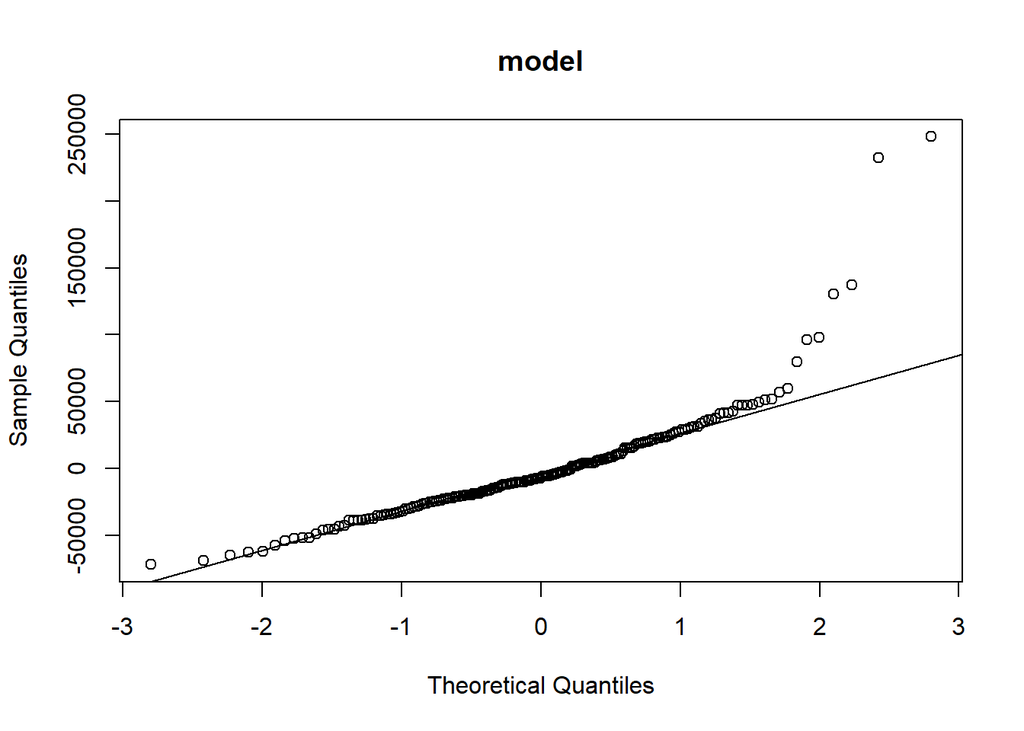

```r
qqnorm(model$residuals,main="model")
qqline(model$residuals)
```

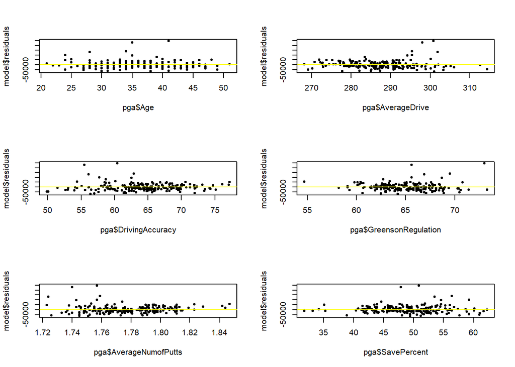

```r
par(mfrow=c(3,2))
plot(pga$Age,model$residuals,pch=20)
abline(h=0,col="yellow")
plot(pga$AverageDrive,model$residuals,pch=20)
abline(h=0,col="yellow")
plot(pga$DrivingAccuracy,model$residuals,pch=20)
abline(h=0,col="yellow")
plot(pga$GreensonRegulation,model$residuals,pch=20)
abline(h=0,col="yellow")
plot(pga$AverageNumofPutts,model$residuals,pch=20)
abline(h=0,col="yellow")
plot(pga$SavePercent,model$residuals,pch=20)
abline(h=0,col="yellow")
```

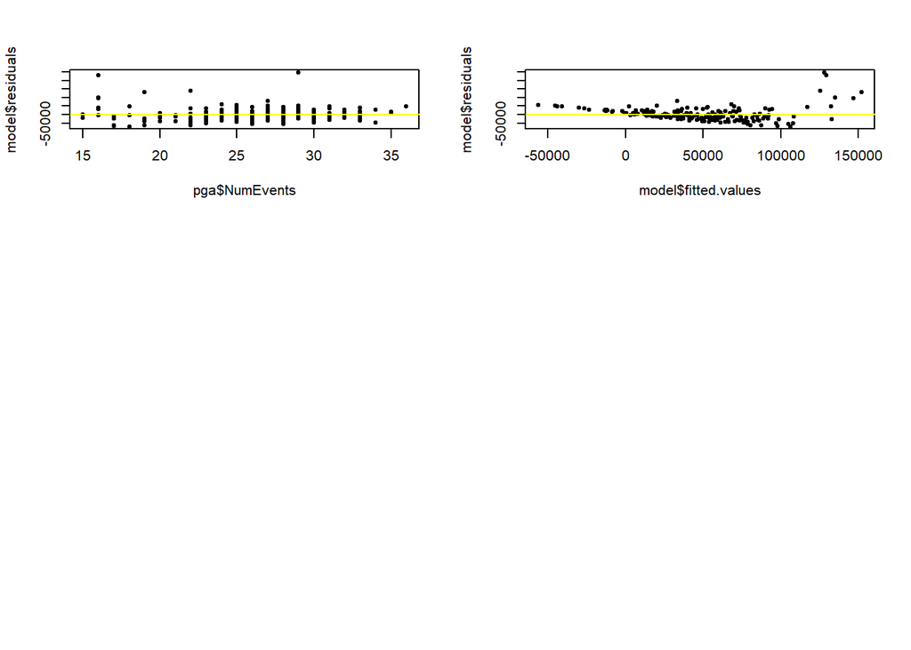

```r
plot(pga$NumEvents,model$residuals,pch=20)
abline(h=0,col="yellow")
# generate residual plot, fitted values vs residual
plot(model$fitted.values,model$residuals,pch=20)
abline(h=0,col="yellow")
```

#### Independent Errors Check (Scatter plot of residuals against time order)

For this data set the Chronology is not known (timestamp), hence we cannot perform this analysis for now.

## Checking with logarithmic response

```r
pga_log_model <- lm(log(AverageWinnings) ~ Age + AverageDrive + DrivingAccuracy + GreensonRegulation + AverageNumofPutts + SavePercent + NumEvents ,data=pga)
summary(pga_log_model)
```

```
##
## Call:
## lm(formula = log(AverageWinnings) ~ Age + AverageDrive + DrivingAccuracy +
##     GreensonRegulation + AverageNumofPutts + SavePercent + NumEvents,
##     data = pga)
##
## Residuals:
##      Min       1Q   Median       3Q      Max
## -1.77513 -0.41331 -0.01228  0.43022  1.73912
##
## Coefficients:
##                      Estimate Std. Error t value Pr(>|t|)
## (Intercept)         33.831322   4.482002   7.548 1.85e-12 ***
## Age                 -0.008215   0.007609  -1.080  0.28169
## AverageDrive        -0.006110   0.008314  -0.735  0.46335
## DrivingAccuracy     -0.020495   0.012514  -1.638  0.10313
## GreensonRegulation   0.190382   0.019105   9.965  < 2e-16 ***
## AverageNumofPutts  -18.457365   2.024330  -9.118  < 2e-16 ***
## SavePercent          0.027000   0.008609   3.136  0.00199 **
## NumEvents           -0.039754   0.009440  -4.211 3.93e-05 ***
## ---
## Signif. codes:  0 '***' 0.001 '**' 0.01 '*' 0.05 '.' 0.1 ' ' 1
##
## Residual standard error: 0.6071 on 188 degrees of freedom
## Multiple R-squared:  0.6358, Adjusted R-squared:  0.6223
## F-statistic: 46.89 on 7 and 188 DF,  p-value: < 2.2e-16
```

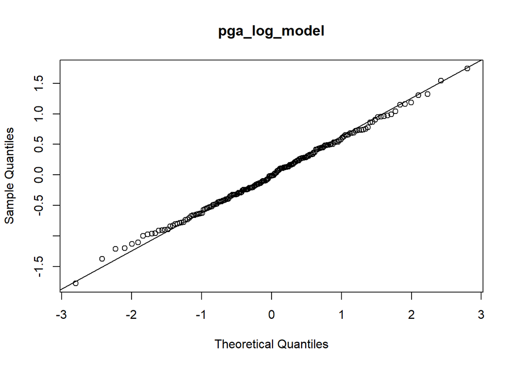

```r
qqnorm(pga_log_model$residuals,main="pga_log_model")
qqline(pga_log_model$residuals)
```

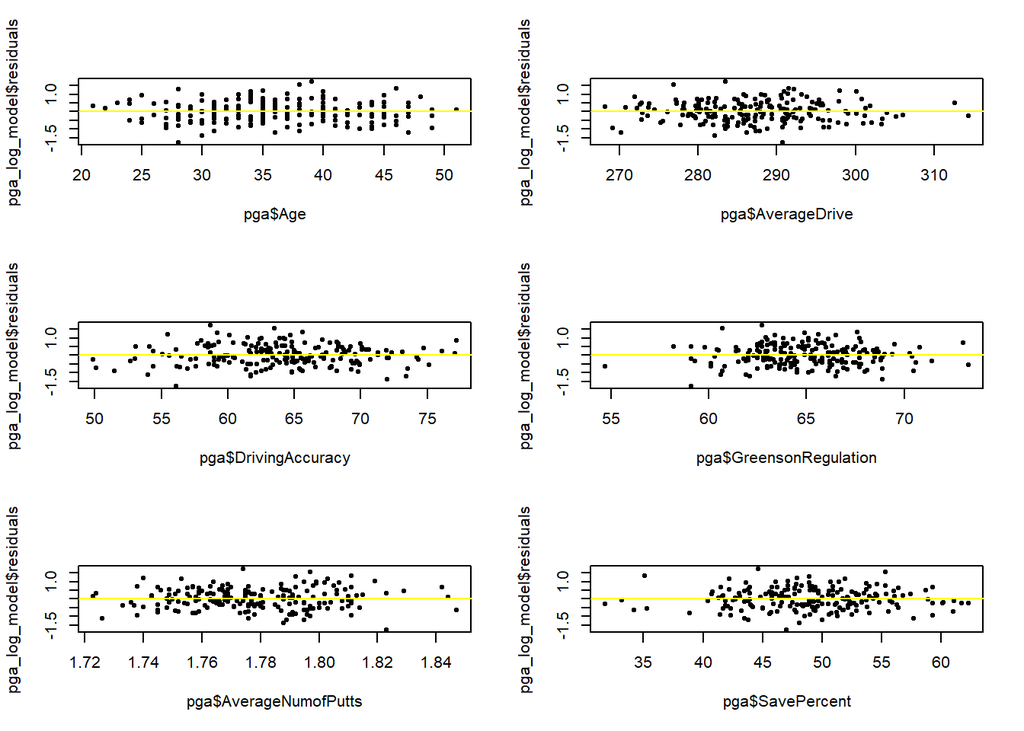

```r
par(mfrow=c(3,2))
plot(pga$Age,pga_log_model$residuals,pch=20)
abline(h=0,col="yellow")
plot(pga$AverageDrive,pga_log_model$residuals,pch=20)
abline(h=0,col="yellow")
plot(pga$DrivingAccuracy,pga_log_model$residuals,pch=20)
abline(h=0,col="yellow")
plot(pga$GreensonRegulation,pga_log_model$residuals,pch=20)
abline(h=0,col="yellow")
plot(pga$AverageNumofPutts,pga_log_model$residuals,pch=20)
abline(h=0,col="yellow")
plot(pga$SavePercent,pga_log_model$residuals,pch=20)
abline(h=0,col="yellow")
```

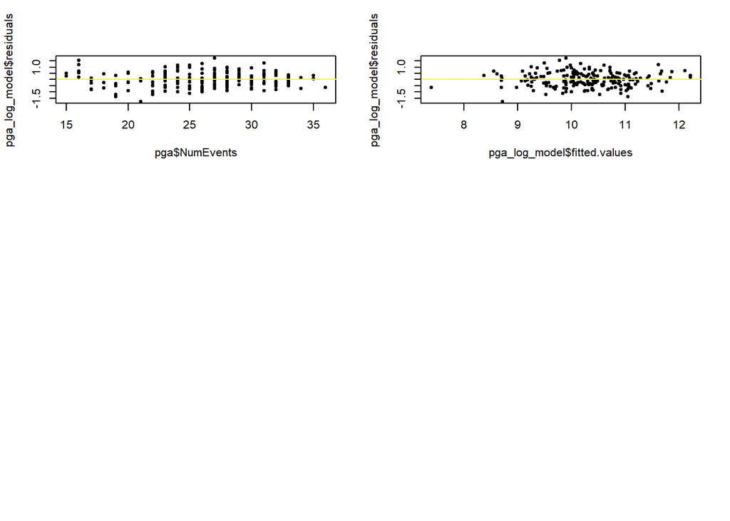

```r
plot(pga$NumEvents,pga_log_model$residuals,pch=20)
abline(h=0,col="yellow")
# generate residual plot, fitted values vs residual
plot(pga_log_model$fitted.values,pga_log_model$residuals,pch=20)
abline(h=0,col="yellow")
```

### Summary of LINE assumptions:

For the logarthmic response, R-squared and Adjusted R-squared are significantly higher than linear response. We can also observe from the residual analysis that plots are following the ‘L,N and E’ assumptions more accurately since no patterns are evident above.